# R Notebook

## Part 1: Data visualization with base R package

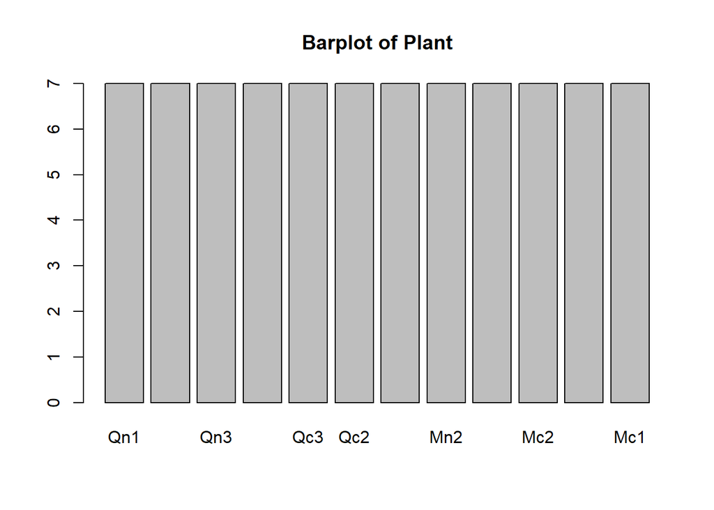

```r
cdata <- as.data.frame(CO2)

barplot(table(cdata$Plant),main = "Barplot of Plant")
```

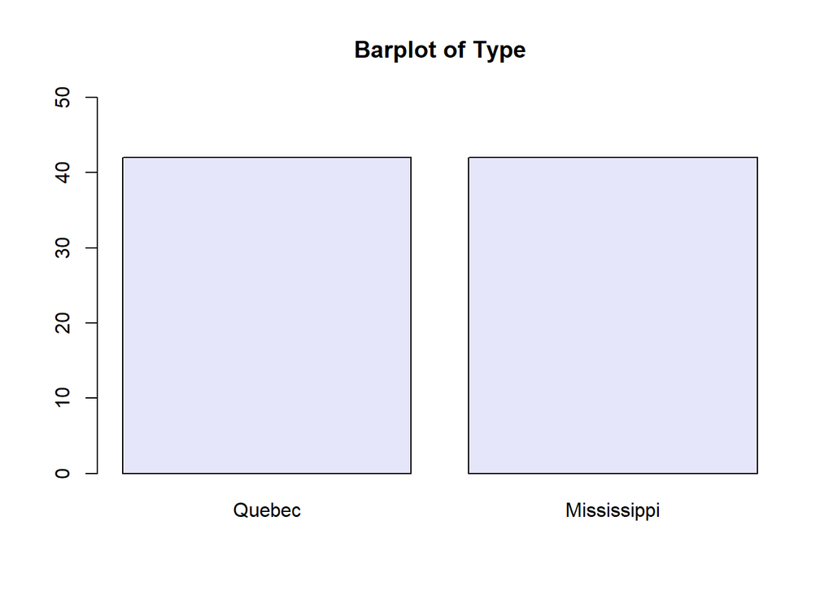

```r
barplot(table(cdata$Type),main = "Barplot of Type",col = "lavender",ylim = range(0,50))
```

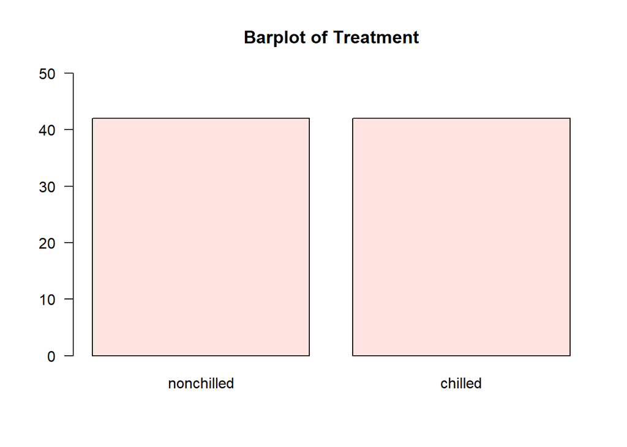

```r
barplot(table(cdata$Treatment),main = "Barplot of Treatment",col = "mistyrose",ylim = range(0,50),las=1)
```

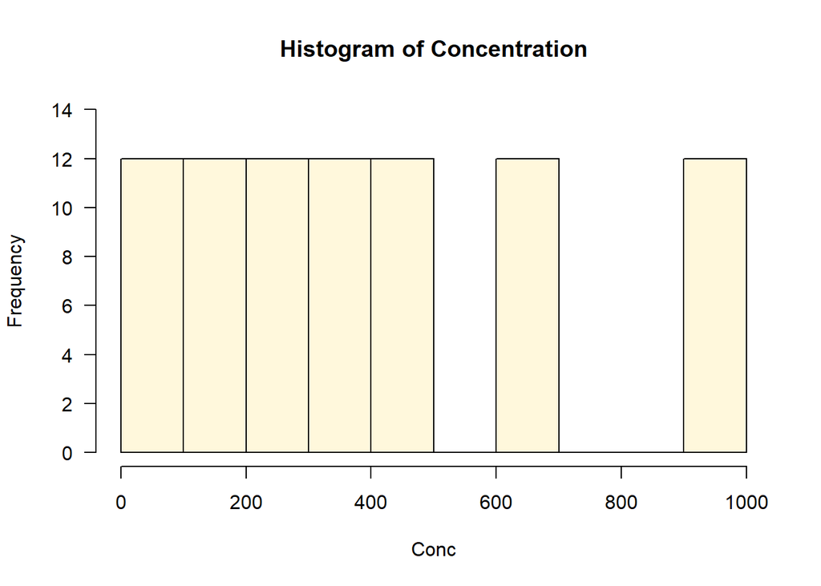

```r
hist(cdata$conc,main = "Histogram of Concentration",col = "cornsilk",xlab = "Conc",ylim = range(0,14),las=1)
```

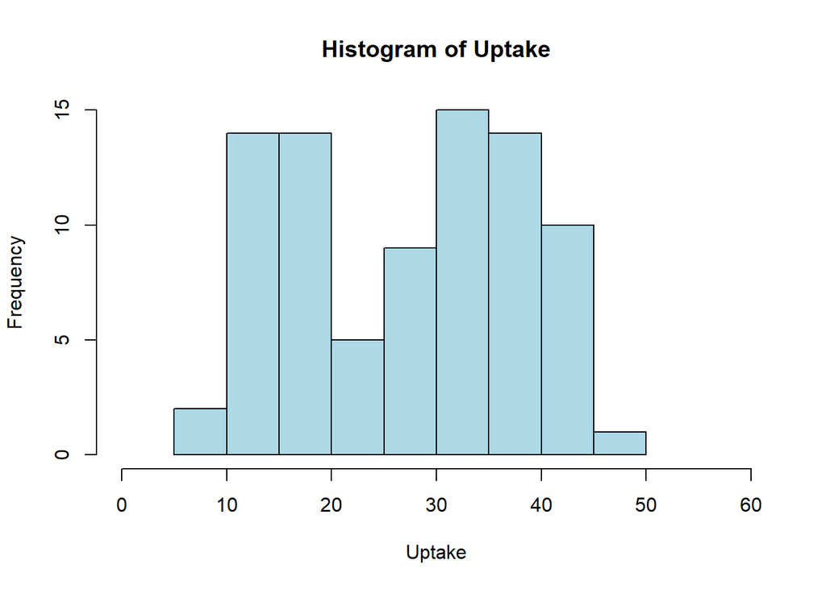

```r
hist(cdata$uptake,main = "Histogram of Uptake",col = "lightblue",xlab = "Uptake",xlim = range(0,60))
```

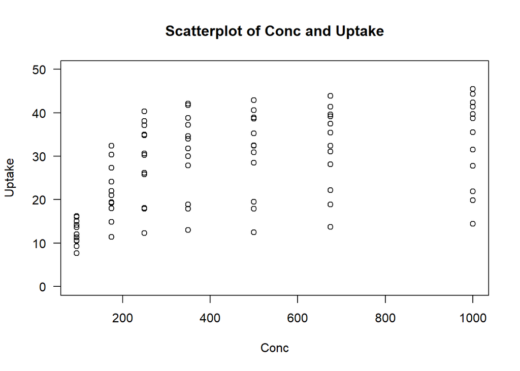

```r
plot(cdata$conc,cdata$uptake, main = "Scatterplot of Conc and Uptake",xlab = "Conc",ylab = "Uptake",ylim = range(0,50),las=1)
```

Interpretation :- In the scatterplot, we can clearly see that the association between the conc and uptake variable is non linear. And thus, correlation should be calculated using spearman method.

```r
cor(cdata$conc,cdata$uptake,method = "spearman")
```

```
## [1] 0.5800041
```

## Part 2 : Data Visualization with ggplot2 package

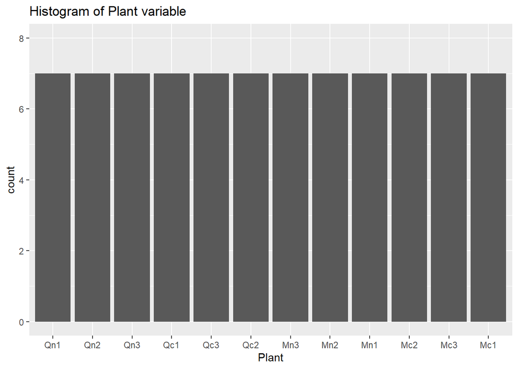

```r
library(ggplot2)
ggplot(data = CO2, aes(Plant))+
  geom_bar()+
  labs(title = "Histogram of Plant variable")+
  ylim(0,8)
```

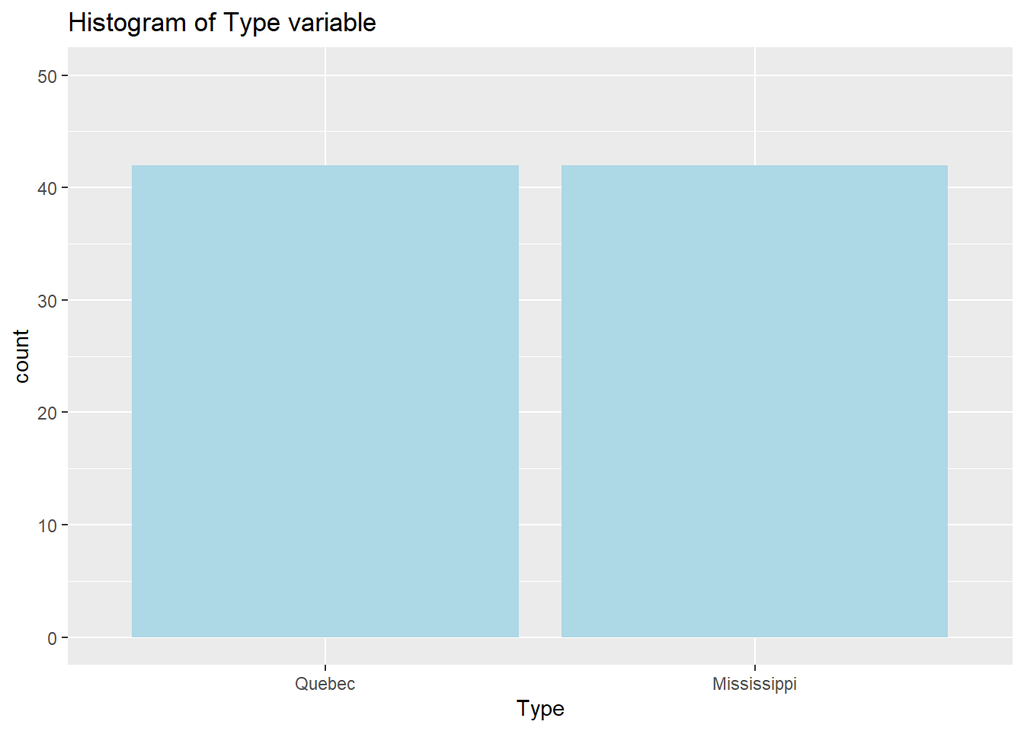

```r
ggplot(CO2,aes(Type))+
  geom_bar(fill="lightblue")+
  ggtitle("Histogram of Type variable")+
  ylim(0,50)
```

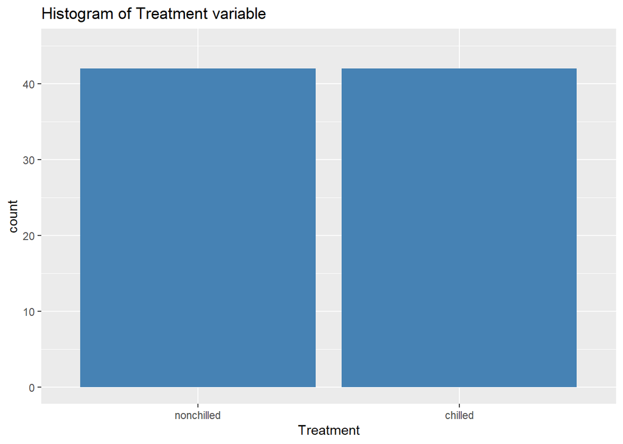

```r
ggplot(CO2,aes(Treatment))+
  geom_bar(fill="steelblue")+
  ggtitle("Histogram of Treatment variable")+
  ylim(0,45)
```

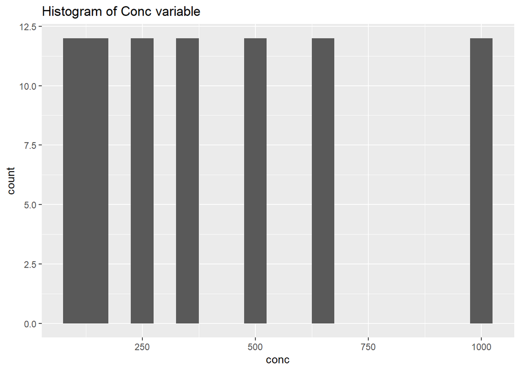

```r
ggplot(CO2,aes(conc))+
  geom_histogram(binwidth = 50)+
  ggtitle("Histogram of Conc variable")
```

```r
  xlab("Conc")
```

```
## $x
## [1] "Conc"
##
## attr(,"class")
## [1] "labels"
```

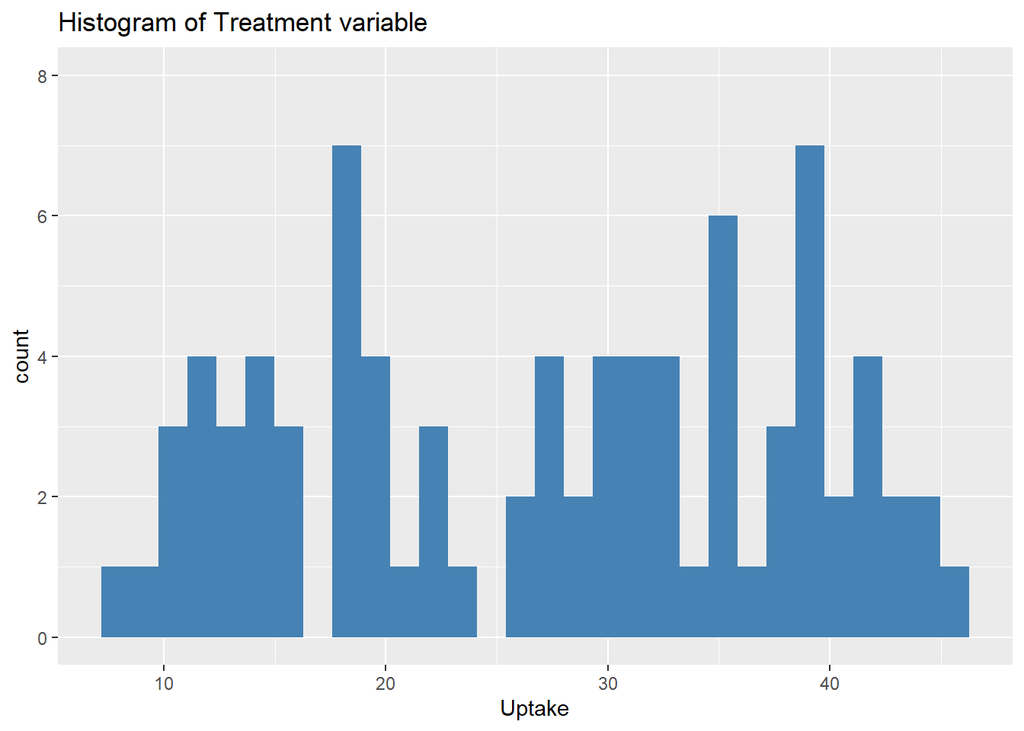

```r
ggplot(CO2,aes(uptake))+
  geom_histogram(fill="steelblue")+
  ggtitle("Histogram of Treatment variable")+
  xlab("Uptake")+
  ylim(0,8)
```

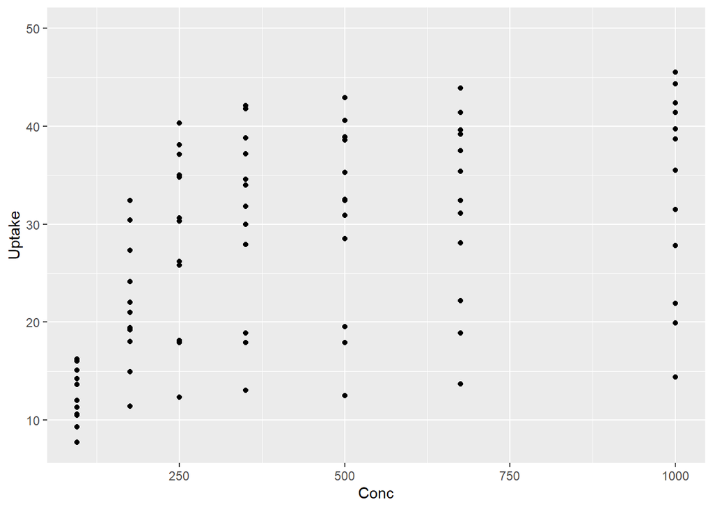

```r
ggplot(CO2,aes(conc,uptake))+
  geom_point()+
  labs(x = "Conc",y = "Uptake")+
  ylim (NA,50)
```

Interpretion :- The conc and uptake variable show the non linear association between them. As the non linear association exist, correlation using spearman method is used.

```r
cor(cdata$conc,cdata$uptake,method = "spearman")
```

```
## [1] 0.5800041
```

## Part 3: Advantages and Limitations of base R and ggplot2 package

ggplot2 is an R package for producing statistical or data graphics. It implements a grammar of graphics based on Wilkinson’s book. Comparison of both are as follows:

-The base idea of ggplot2 is to split a chart into graphical objects,data, scale, coordinate system, annotation and think about it separately. On the other hand, function in base R graphics specify everything in the function arguments. In ggplot2 ‘+’ symbol is used to separate the different layers whereas in base R, comma(,) separates the arguments in the function.

-ggplot2 some built in data management. For example ‘bin’ for barplot. It automatically creates the bin and count the each element in the bin. In base R ‘table’ that is outside of the visualization function is used.

-ggplot2 has the consistent syntax. The idea is to create the different layers and ‘+’ symbol separating those symbols. The cons is, it has different type of syntax then rest of R.

-ggplot2 is the powerful function for visualization,can easily create complex graph compared to base R package.

-Base R package is simple, faster and straight forward than ggplot2. ggplot2 is slower than base R package. But the syntax of the Base R package will be heavy for the complex graph.

## Part 4: Text analysis with base/ggplot packages and Social Network Analysis with igraph package

```r
# Loading the termDocMatrix
load("termDocMatrix.rdata")

#Converting to matrix
tmatrix <- as.matrix(termDocMatrix)
class(tmatrix)
```

```
## [1] "matrix" "array"
```

```r
#Getting the term frequency
freq <- sort(rowSums(tmatrix),decreasing = T)
freq
```

```
##            r         data       mining     analysis      package        users
##           83           63           52           23           23           18
##     examples      network     tutorial       slides     research       social
##           17           17           17           16           15           12
##    positions postdoctoral    computing introduction applications         code
##           11           11           10           10            9            9
##     parallel       series         time
##            8            8            8
```

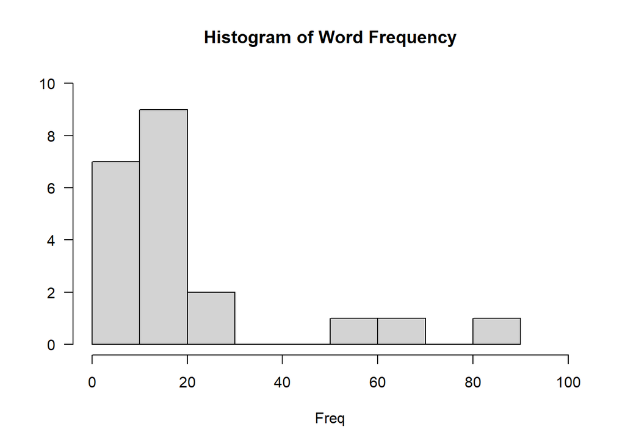

```r
hist(freq,main = "Histogram of Word Frequency", xlab = "Freq",ylab = NULL,xlim = range(0,100),ylim = range(0,10),las=1)
```

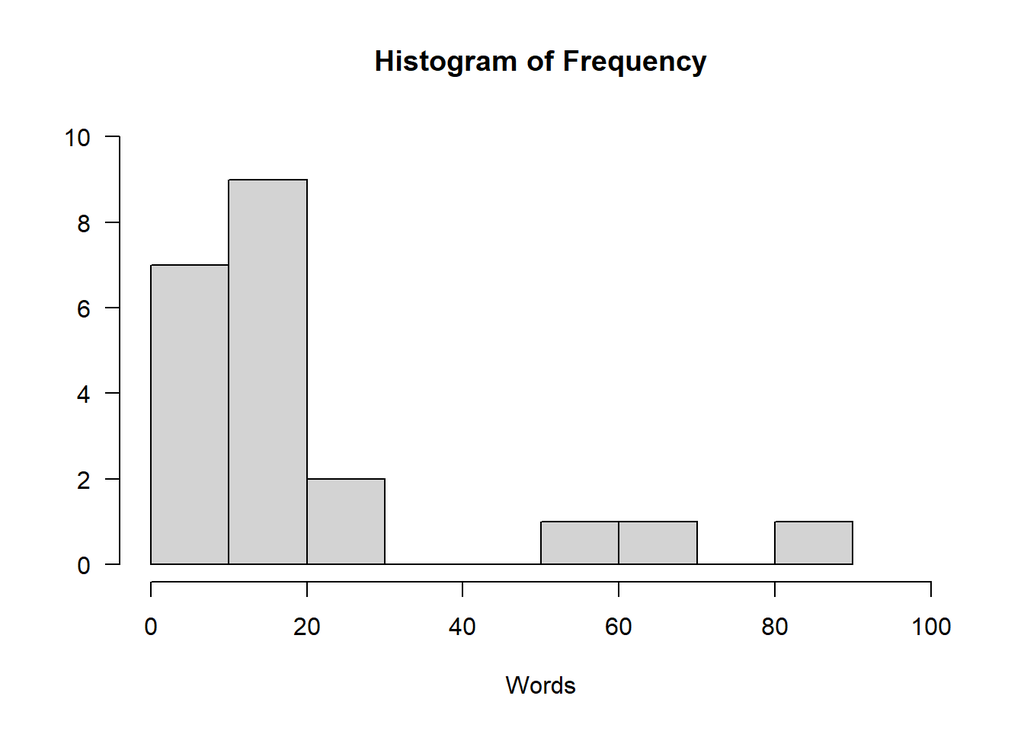

```r
hist(freq,main="Histogram of Frequency", xlab = "Words",ylab=NA,xlim = range(0,100),ylim = range(0,10),las = 1)
```

```r
#Creating histogram for frequency greater than or equal to 5 using ggplot2 package
dmatrix <- as.data.frame(tmatrix)
freq1 <- rowSums(dmatrix)
freq1
```

```
##     analysis applications         code    computing         data     examples
##           23            9            9           10           63           17
## introduction       mining      network      package     parallel    positions
##           10           52           17           23            8           11
## postdoctoral            r     research       series       slides       social
##           11           83           15            8           16           12
##         time     tutorial        users
##            8           17           18
```

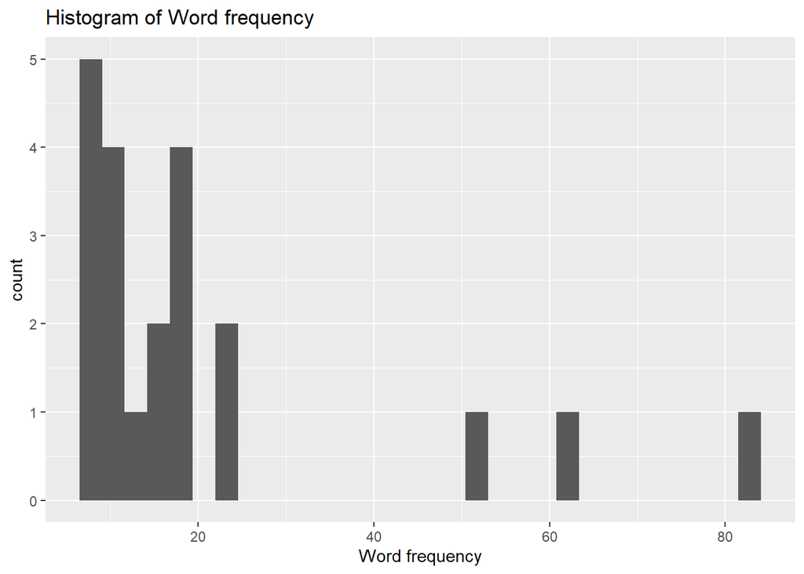

```r
ggplot(dmatrix[which(freq1 >=5)],aes(freq))+
  geom_histogram()+
  ggtitle("Histogram of Word frequency")+
  labs(x = "Word frequency",y="count")
```

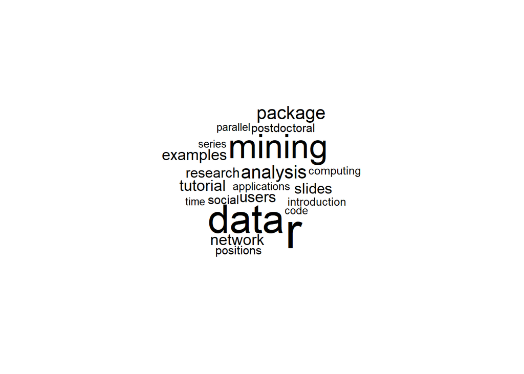

```r
#Creating word cloud
library(wordcloud)
wordcloud(words=names(freq),freq = freq,random.order = T)
```

## Performin Social Network Analysis

```r
#Converting each cell matrix to 1 if greater than 1 and creating a transition matrix
tmatrix[tmatrix > 1] = 1
tranmatrix <- tmatrix %*% t(tmatrix)
tranmatrix[5:9,5:9]
```

```
##               Terms
## Terms          data examples introduction mining network
##   data           53        5            2     34       0
##   examples        5       17            2      5       2
##   introduction    2        2           10      2       2
##   mining         34        5            2     47       1
##   network         0        2            2      1      17
```

```r
library(igraph)
gp <- graph.adjacency(tranmatrix,mode = "undirected",weighted = T)
simplify(gp)
```

```
## IGRAPH 2747d81 UNW- 21 130 --
## + attr: name (v/c), weight (e/n)
## + edges from 2747d81 (vertex names):
##  [1] analysis    --code         analysis    --data
##  [3] analysis    --examples     analysis    --introduction
##  [5] analysis    --mining       analysis    --network
##  [7] analysis    --package      analysis    --positions
##  [9] analysis    --postdoctoral analysis    --r
## [11] analysis    --research     analysis    --series
## [13] analysis    --slides       analysis    --social
## [15] analysis    --time         analysis    --tutorial
## + ... omitted several edges
```

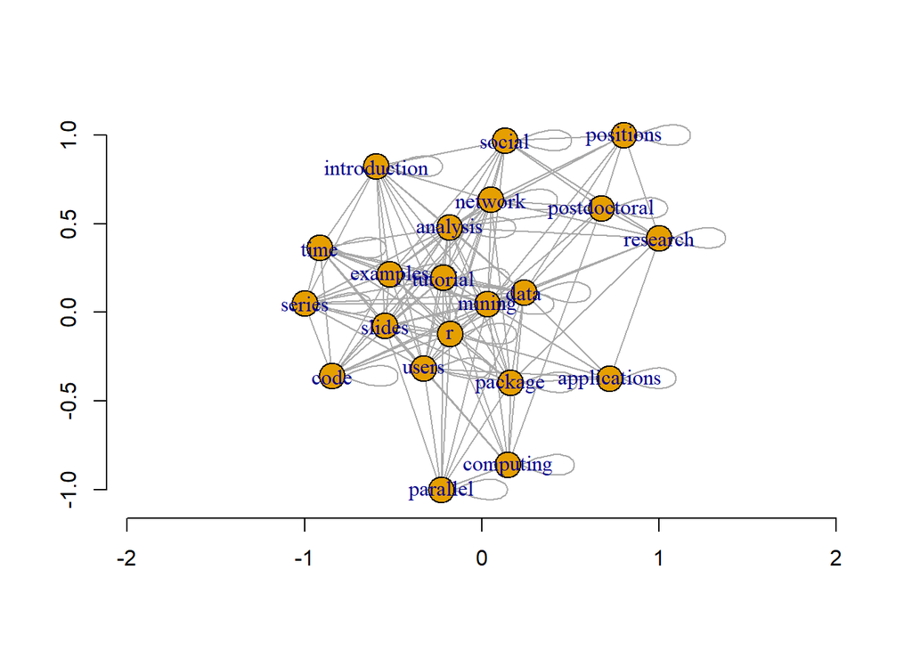

```r
V(gp)$label <- V(gp)$name
V(gp)$degree <- degree(gp)

set.seed(3952)
layout1 <- layout.fruchterman.reingold(gp)
plot(gp,layout1)
```

Interpretation : Here sna graph is plotted, where nodes are the words in ther termDocMatrix and links defines the relation with other words.